# Sushi-Roll Model of Online Media

Previously: “pizza model”, “salami model”

Author

Tom Cunningham, [Integrity Institute](https://integrityinstitute.org/)

Published

September 8, 2023

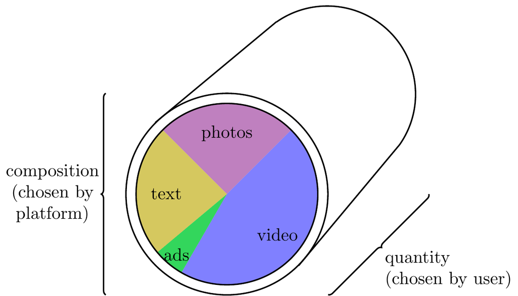

**A model of internet media: the platform chooses the *composition*, the user chooses the *quantity*.** I think this is a nice crisp way of modeling how media platforms (FB, YouTube, TikTok) make their decisions about content: they chooses the *mix* of content, i.e. the shares of each type, and then their users choose the *quantity*. The platform is choosing the fillings for the sushi roll and the consumer is choosing how much to eat. Their decisions jointly determine the total amount of each ingredient consumed.

**This gives a unified model of feed ranking inclusive of ad-load, revenue-sharing, producer-side effects, and advertiser demand elasticity.**

We can break down four different ways in which increasing the share of a given content-type $i$ will affect total revenue:

1. **Consumption incrementality.** The effect on total impressions, AKA incrementality. In general platforms are always trying to find the types of content that increase total long-run consumption for a given user.
2. **Price.** The price received by the platform for each impression of content-type $i$. For ads this is positive, but platforms also sometimes license content or pay a revenue-share, in which case the price is negative.
3. **Price elasticity.** The effect of quantity on price. E.g. when we increase the number of ad impressions shown this will lower the market price for all other ad-impressions, and so this is a reason to limit the quantity of ads.
4. **Production elasticity.** The effect on production by producers. Some producers will produce more content when they receive more impressions, and so this is an additional benefit of increasing their share of impressions.

An efficient mix of content will choose the shares such that each type of content has the same marginal value, i.e. for each the type four components of value all sum to the same number.

**Related literature.** There are some nice models of ad-media tradeoff in Anderson and Jullien (2015), but I believe they don’t consider the effects on production by producers, nor the tradeoff between different types of content (though it’s a long time since I read it).

**Expressed formally:** Suppose the platform chooses $x_1,\ldots,x_n$ which represent the impression-shares of each type of content such that $\sum_{i=1}^nx_i=1$. User demand depends on the average quality of each type of content ($q_i$), and they have diminishing returns in each type of content. The platform receives $p_i$ for showing an impression of type $i$, but that price depends on the number of impressions-seen. We can write the maximization problem as:

$$\begin{aligned}
\max_{x_1,\ldots,x_n} \utt{\left(\sum_{i=1}^n q_i(x_i)x_i^\gamma\right)}{total}{impressions}
\utt{\left(\sum_{i=1}^n x_ip_i(x_i)\right)}{avg revenue}{per impression}
,\text{ s.t. }\sum_{i=1}^n x_i=1
\end{aligned}$$

The first order condition shows us the four components of value:

$$\frac{\partial L}{\partial x_i} =
\ut{
(\utt{q_i \gamma x_i^{-(1-\gamma)}}{incrementality}{}
+ \utt{q_i'(x_i)x_i^\gamma}{effect through}{quality})
\utt{\left(\sum_{j=1}^n p_j x_j\right)}{avg revenue}{per impression}
}{effect on revenue through total impressions}
+
\utt{
(
\utt{p_i(x_i)}{revenue from}{additional impressions}+
\utt{p'_i(x_i)x_i}{revenue from}{change in price}
)
\utt{\left(\sum_{j=1}^n q_j x_j^{\gamma}\right)}{total}{impressions}}
{effect on revenue}{through impressions on $i$}
+ \utt{\lambda}{avg marginal}{effect}=0$$

The final term, $\lambda$, is the Lagrangian, representing the average marginal value of the outside option, i.e. the other types of content that are being replaced. In some cases we can simplify this model and we get a closed-form solution for the optimal content composition.

**What this model doesn’t include:**

- *The effect of consumption on production.* E.g. we sometimes want to reduce ad-load to increase production by users, or we want to show users friend posts because it increases production (“mimicry”). You could incorporate this by defining $x_{i,j}$ as the share shown from producer $i$ to consumer $j$, and then each user’s production depends both on (1) how many impressions they get on their content; (2) composition of impressions that they give to other content.
- *Setting a price for production (revenue sharing).* In this model the platform’s choice variables are just the quantities, $x_i$. However for revenue-sharing it seems that the platform is setting a *price*, with the goal of increasing producer quality. I don’t think you can model this such that price is a function of quantity (as we do with ads). I think you need to keep track of two separate things: (1) what happens when I give this producer more distribution; (2) what happens when I pay this producer to produce.

## More Details

We can walk through a series of models from simple to complicated, to build up to the full sushi-roll model:

1. **Platform chooses share of ads.** The platform chooses the share of impressions that are ads, and consumers choose how many total impressions to consume. If we assume the price of ads (CPMs) is fixed then the platform will set the ad-load to maximize the total number of ad-impressions. If the platform can influence the price of ads by their choice of quantity (i.e. they act as a monopolist) then the platform may choose to reduce ad-load to drive up CPMs.[^1]

   This model is easy to state but I think is primarily applicable to *small* platforms where they take prices as given. E.g. suppose you run an app where you (1) license certain content, or use user-generated content; (2) run ads from various different ad networks, the ads vary in CPMs but they also vary in incrementality (i.e. how obnoxious they are to your userbase).

   Because prices are taken as given, this model doesn’t help us calculate the optimal revenue share. It will tell us the optimal ad-load, but not taking into account the elasticity of supply from the advertiser.

   Note that most platforms do not explicitly discriminate between advertisers based on their incrementality however they can implicitly discriminate by having a “quality score” or “organic bid”. This score is quite clearly designed to measure the incrementality of the advertisements, and so I think can be used to implement an efficient pricing scheme.
4. **Platform choses shares of ads and organic content, prices endogenous.** We can easily extend the model above to allow the price of each type of content to depend on the quantity shown ($p_i(x_iM)$). For example the price of ads will depend on the number of ad impression shown (due to advertisers’ diminishing marginal returns from ads shown). This gives platforms a reason to restrict the quantity of ad-impressions.
5. **Platform chooses both shares and prices.** Up to this point the platform chose only the share of each type of content.

   Now suppose the platform can set a price to pay producers (e.g. “revenue share”), and it’s a homogenous price. The price should roughly depend on (1) the producer’s elasticity of quality to price (i.e. their cost function), and (2) the incrementality of quality on the consumer side. We could set this up with a single price for all producers, or set a producer-specific price.

<sup>1</sup> In the profit-maximizing solution *either* the consumer-side or advertiser-side first-order-condition will be binding. It depends on the relative elasticity of the two sides of the platform.

## Model 1: Platform Chooses Ad-Load

(see previous paper)

## Model 2: Platform Chooses Organic Composition

We have a model where there are $n$ producers, the platform assigns to each producer a share of total content $x_i$, with $\sum_ix_i=1$, and the consumer will choose how many total impressions to consume ($M$) based on the average quality, but with diminishing returns in each .

$$\begin{aligned}
q_i &\in \mathbb{R}^+
&& \text{quality of producer $i$} \\
x_i &\in [0,1]
&& \text{share of impressions on producer $i$}\\
\sum_i x_i &= 1
&& \text{shares must sum to 1}\\
M &= \sum_{i=1}^nq_ix_i^\gamma
&& \text{total impressions, diminishing returns in each producer, $0<\gamma<1$} \\
\end{aligned}$$

The platform wishes to maximize total impressions, $M$. We want to solve for the resultant impression-share of each producer, i.e. $x_i$ as a function of the qualities $q_1,..,q_n$ and parameter $\gamma$. We get the following impression-maximizing shares:

$$x_i=\frac{q_i^\frac{1}{1-\gamma}}{\gamma\sum_{j=1}^nq_j^\frac{1}{1-\gamma}}.$$

**Adding money.** Suppose now that the platform gets paid for showing certain impressions. We can make various different assumption about the price paid:

1. Uniform homogenous price: the platform takes the price as given. This only makes sense if there are a subset of producers who are advertisers.
2. Each producer sets a payment rate per impression.
3. The platform chooses a single price for all producers to get extra impressions.

## Model 3: Platform Chooses Composition, Prices Fixed

$$\begin{aligned}
q_i &\in \mathbb{R}
&& \text{quality of producer $i$} \\
p_i &\in \mathbb{R}
&& \text{price offered by producer $i$} \\
x_i &\in [0,1]
&& \text{share of impressions on producer $i$}\\
\sum_i x_i &= 1
&& \text{shares must sum to 1}\\
M &= \sum_{i=1}^nq_ix_i^\gamma
&& \text{total impressions, diminishing returns in each producer, $0<\gamma<1$} \\
\end{aligned}$$

If the platform simply wanted to maximize total impressions, $M$, then they can derive the optimal impression-shares as follows:

$$x_i^*=\frac{q_i^\frac{1}{1-\gamma}}{\gamma\sum_{j=1}^nq_j^\frac{1}{1-\gamma}}.$$

However we want the platform to maximize profit, which we can write as follows:

$$\begin{aligned}
\text{profit} &= \utt{\left(\sum_{i=1}^n q_ix_i^\gamma\right)}{total}{impressions}
\utt{\left(\sum_{i=1}^n x_ip_i\right)}{avg revenue}{per impression}
\end{aligned}$$

I’m not sure if we can get a closed-form solution but we can at least get a first-order condition for each $x_i$ that tells us useful stuff about comparative statics:

$$\frac{\partial L}{\partial x_i} =
\ut{\utt{q_i \gamma x_i^{-(1-\gamma)}}{effect on}{total impressions}
\utt{\left(\sum_{j=1}^n p_j x_j\right)}{avg revenue}{per impression}
}{effect on revenue through total impressions}
+
\utt{p_i\utt{\left(\sum_{j=1}^n q_j x_j^{\gamma}\right)}{total}{impressions}}
{effect on revenue}{through impressions on $i$}
+ \utt{\lambda}{avg marginal}{effect}=0$$

## Model 4: Platform Chooses Composition, Monopolist

Now we allow the price of each type of content to depend on the quantity used, e.g. the price of ads will be higher when the quantity of ad-impressions is smaller (monopolist in the ad market). Strictly we should write $p_i(Mx_i)$, but it’s somewhat easier to write $p_i(x_i)$ and the answer should be similar for any type of content that is a small share.

$$\begin{aligned}
\text{profit} &= \utt{\left(\sum_{i=1}^n q_ix_i^\gamma\right)}{total}{impressions}
\utt{\left(\sum_{i=1}^n x_ip_i(x_i)\right)}{avg revenue}{per impression}
\end{aligned}$$

There’s now one additional term in the first order condition:

$$\frac{\partial L}{\partial x_i} =
\ut{\utt{q_i \gamma x_i^{-(1-\gamma)}}{effect on}{total impressions}
\utt{\left(\sum_{j=1}^n p_j x_j\right)}{avg revenue}{per impression}
}{effect on revenue through total impressions}
+
\utt{
(
\utt{p_i(x_i)}{revenue from}{additional impressions}+
\utt{p'_i(x_i)x_i}{revenue from}{change in price}
)
\utt{\left(\sum_{j=1}^n q_j x_j^{\gamma}\right)}{total}{impressions}}
{effect on revenue}{through impressions on $i$}
+ \utt{\lambda}{avg marginal}{effect}=0$$

The additional term represents the platform’s monopoly power with respect to the price paid. This has a natural interpretation for advertisers: showing fewer ads will drive up the price. For paid content-providers it could perhaps represent bulk discounts, I’m not sure whether this is a significant consideration.

## Model 2 Derivation

This is derivation of model #2. (I had chatGPT help with this derivation, was very useful)

1. **Setting up the Lagrangian.** The objective is to maximize the total impressions, $M$, subject to the constraint that the allocated shares of impressions sum to one. We start by writing the Lagrangian:
   $$\mathcal{L} = \sum_{i=1}^n q_i x_i^\gamma - \lambda \left(\sum_{i=1}^n x_i - 1\right)$$

   where $\lambda$ is the Lagrange multiplier associated with the constraint.
2. **Solving for the multiplier.** To solve for the value of $\lambda$, we take the derivative of the Lagrangian with respect to $x_i$ and set it equal to zero:
   $$\frac{\partial \mathcal{L}}{\partial x_i} = \gamma q_i x_i^{\gamma - 1} - \lambda = 0$$

   Rearranging this equation yields:
   $$x_i = \left(\frac{\lambda}{\gamma q_i}\right)^{\frac{1}{\gamma-1}}$$

   Taking the sum of this expression over all producers and using the constraint that the shares of impressions must sum to one, we obtain:
   $$1 = \sum_{i=1}^n x_i = \sum_{i=1}^n \left(\frac{\lambda}{\gamma q_i}\right)^{\frac{1}{\gamma-1}}$$

   Simplifying this equation gives:

   $$\lambda^{\frac{1}{\gamma-1}} = \gamma \sum_{i=1}^n q_i^{-\frac{1}{\gamma-1}}$$

   Substituting this expression for $\lambda$ back into the equation for $x_i$ results in:

   $$x_i = \frac{q_i^{-\frac{1}{\gamma-1}}}{\gamma \sum_{j=1}^n q_j^{-\frac{1}{\gamma-1}}}$$

   This is our final expression for the share of impressions on each producer as a function of the exogenous qualities and $\gamma$.

**Summary:**

The Lagrangian: $\mathcal{L} = \sum_{i=1}^n q_i x_i^\gamma - \lambda \left(\sum_{i=1}^n x_i - 1\right)$.

Expression for the multiplier:
$$\lambda^{\frac{1}{\gamma-1}} = \gamma \sum_{i=1}^n q_i^{-\frac{1}{\gamma-1}}$$

The resultant expression for $x_i$:
$$x_i = \frac{q_i^{-\frac{1}{\gamma-1}}}{\gamma \sum_{j=1}^n q_j^{-\frac{1}{\gamma-1}}}.$$

Slightly rearranged (by me):

$$x_i=\frac{q_i^\frac{1}{1-\gamma}}{\gamma\sum_{j=1}^nq_j^\frac{1}{1-\gamma}}.$$

## References

Anderson, Simon P., and Bruno Jullien. 2015. “Chapter 2 - the Advertising-Financed Business Model in Two-Sided Media Markets.” In *Handbook of Media Economics*, edited by Simon P. Anderson, Joel Waldfogel, and David Strömberg, 1:41–90. Handbook of Media Economics. North-Holland. https://doi.org/https://doi.org/10.1016/B978-0-444-62721-6.00002-0.